# Forward Return Prediction Data Report

Yawen Hu

November 17, 2020

## **Overview:**

[output not shown]

### **Part 0. Data Preparation**

*The code for this part can be found in `data_prep.R`.*

**`data_prep.R`**

```r
## Data Preparation Part:
##
## In this part, we get the backward return data we need to use for the prediction.
##
## Author: Yawen Hu
## Updated: November 17, 2020

# 79: -------------------------------------------------------------------------

# libraries: ------------------------------------------------------------------
library(tidyverse)
# directories: ----------------------------------------------------------------
setwd("~/Desktop/urop/data")

# data: -----------------------------------------------------------------------
price = read_delim("price_data.csv", delim = ",")
bret_refer = read_delim("bret_ori.csv", delim = ",")

# function: --------------------------------------------------------------------
backward_return = function(a, h, data = price) {
  # Inputs:
  #     a - The asset number.
  #     h - represent h-min backward return.
  #     data - default to be `price` dataset.
  # Outputs:
  #     the vector of h-min backward return of asset a.
  asset = paste0("Asset_", a)
  data =  data %>% dplyr::select(-X1)
  start_price = as.numeric(data[1, a])
  data = data %>%
    mutate(
      lag = DataCombine::shift(.data[[asset]], shiftBy = -h),
      lag = ifelse(is.na(lag), start_price, lag)
    ) %>%
    transmute( br = (.data[[asset]] - lag) / .data[[asset]] )
  return (as.vector(data$br))
}

forward_return = function(h, data = price) {
  # Inputs:
  #     h - represent h-min forward return
  #     data - default to be `price` dataset
  # Outputs:
  #     the vector of h-min forward return of asset 1.
  last_price = as.numeric(data[524160, 2])
  data = data %>%
    mutate(
      lead = DataCombine::shift(Asset_1, shiftBy = h),
      lead = ifelse(is.na(lead), last_price, lead)
    ) %>%
    transmute( fr = (lead - Asset_1) / Asset_1 )
  return (as.vector(data$fr))
}

bret_dataframe = function(df, i, j) {
  varname = paste0("Asset_", i, "_BRet_", j)
  df[[varname]] = with(df, backward_return(i, j))
  return (df)
}

# bret: h - min backward return with Asset 1, 2, 3:
bret = price
for(j in c(3,10,30,60,120,180,240,360,480,600,720,960,1200,1440)){
  for(i in 1:3){
    bret = bret_dataframe(bret, i, j)
  }
}

fret = bret %>%
  select(-c(1:4)) %>%
  mutate( Asset_1_FRet_10 = forward_return(10) )

save(fret, price, backward_return, bret_dataframe, file = "price_data.RData")


# 79: -------------------------------------------------------------------------
```

### **Part I. Regression**

##### *In the regression part, we fitted four models using different methods:*

- Linear Regression
- K-th Nearest Neighbor
- Ridge
- LASSO

By comparing the out-of-sample correlation between the true value and predicted value, we choose the best method for prediction.  
*The code of computation can be found in `data_analysis.R`.*

```
Warning in readLines("./data_analysis.R"): incomplete final line found on './
data_analysis.R'
```

```r
## Data Analysis Part:
##
## This part includes the regression models we fitted on the data set we
## generated in the data preparation part.
##
## Author: Yawen Hu
## Updated: November 17, 2020

# 79: -------------------------------------------------------------------------

# directories: ----------------------------------------------------------------
setwd("~/Desktop/urop")

# libraries: ------------------------------------------------------------------
library(tidyverse)
library(ggplot2)
library(FNN)
library(glmnet)

# data: -----------------------------------------------------------------------
foo = load("./data/price_data.RData")

# Regression Models : ---------------------------------------------------------

## 1.Linear regression: -------------------------------------------------------

### (1) Predictors: 3-min, 10-min, 30-min backward return of Asset 1, 2, 3.
fret_lm = fret %>%
  dplyr::select( Asset_1_FRet_10, ends_with(c("_3", "_10", "_30")) )

### (2) Set training data (70%) and testing data (30%).
train_size = nrow(fret_lm)*0.7
train_id = 1:train_size

train_lm <- fret_lm[train_id, ]
test_lm <- fret_lm[-train_id, ]

### (3) Fit Linear Model - lmod.
lmod = lm(Asset_1_FRet_10 ~., train_lm)
summary(lmod)

#### (4) In-sample and Out-of-sample correlation.

##### in-sample correlation:
y_true_train_lm = train_lm$Asset_1_FRet_10
y_pred_train_lm = predict(lmod, train_lm)
cor_in_sample_lm = cor(y_true_train_lm, y_pred_train_lm)

##### out-of-sample correlation:
y_true_test_lm = test_lm$Asset_1_FRet_10
y_pred_test_lm = predict(lmod, test_lm)
cor_out_sample_lm = cor(y_true_test_lm, y_pred_test_lm)


#### (5) Plot of rolling correlation between y_pred and y_true:
lm_plot = fret_lm %>%
  mutate( Asset_1_FRet_10_pred = predict(lmod, fret_lm) ) %>%
  transmute( y_true = Asset_1_FRet_10, y_pred = Asset_1_FRet_10_pred )

Rho = c()
for(i in 1:524160){
  if(i <= 30240){
    Rho[i] = cor(lm_plot[c(1:i), 1], lm_plot[c(1:i), 2])
  }
  else{
   Rho[i] = cor(lm_plot[c((i-30240):i), 1], lm_plot[c((i-30240):i), 2])
  }
}

lm_plot = lm_plot %>% mutate( time = c(1:524160), Rho = Rho )
# write_csv(lm_plot, "liner_model.csv")
#lm_plot = read_csv("./data/liner_model.csv")

lm_corr_plot = lm_plot %>%
  filter(!is.na(Rho)) %>%
  ggplot2::ggplot( aes(x = time, y = Rho) ) +
  ggplot2::geom_point( colour = 'skyblue4', size = 0.5 ) +
  xlab("time (min)") +
  ylab("correlation") +
  ggtitle("Three-week backward rolling correlation between y_true and y_pred") +
  theme(plot.title = element_text(hjust = 0.5))
print(lm_corr_plot)

# ggsave("corr_lm.png")

## 2. KNN: --------------------------------------------------------------------

### (1) Predictors: 3-min, 10-min, 30-min backward return of Asset 1, 2, 3.
fret_knn = fret %>%
  dplyr::select( Asset_1_FRet_10, ends_with(c("_3", "_10", "_30")) )

### (2) Set training data (70%) and testing data (30%).
train_size <- nrow(fret_knn)*0.7
train_id <- 1:train_size

train_KNN <- fret_knn[train_id, ]
test_KNN <- fret_knn[-train_id, ]

### (3) Find best K value by testing MSE.
#### Train:
k_range = c(5, 25, 125, 625)
trainMSE_KNN = c()
train_x = train_KNN %>% dplyr::select(-Asset_1_FRet_10)

for(i in 1:length(k_range)) {
  knnTrain <-knn.reg(train = train_x,
                     y = train_KNN$Asset_1_FRet_10,
                     test = train_x,
                     k = k_range[i])

  trainMSE_KNN[i] = mean((train_KNN$Asset_1_FRet_10 - knnTrain$pred)^2)
}

#### Test:
testMSE_KNN = c()
test_x = test_KNN %>% dplyr::select(-Asset_1_FRet_10)

for(i in 1:length(k_range)) {
  knnTest <-knn.reg(train = train_x,
                    y = train_KNN$Asset_1_FRet_10,
                    test = test_x,
                    k = k_range[i])

  testMSE_KNN[i] <-mean((test_KNN$Asset_1_FRet_10 - knnTest$pred)^2)
}

#### Plot training and testing MSE:
plot(trainMSE_KNN ~ k_range, type = "b", lwd = 2, col = "blue",
     main = "Training and Test MSE for KNN", xlab = "K", ylab = "MSE")
lines(testMSE_KNN ~ k_range, type = "b", lwd = 2, col = "red")

### Find Best k:
best_k = k_range[which.min(testMSE_KNN)]
X = fret_knn %>% dplyr::select(-Asset_1_FRet_10)
knn_best_k <-knn.reg(train = train_x,
                     y = train_KNN$Asset_1_FRet_10,
                     test = X,
                     k = best_k)
KNN_Pred_bestK = knn_best_k$pred

### (4) Correlation:
#### in-sample correlation
y_true_train_KNN = train_KNN$Asset_1_FRet_10
y_pred_train_KNN = KNN_Pred_bestK[1:nrow(train_KNN)]
cor_in_sample_KNN = cor(y_true_train_KNN, y_pred_train_KNN)

#### out-of-sample correlation
y_true_test_KNN = test_KNN$Asset_1_FRet_10
y_pred_test_KNN = KNN_Pred_bestK[(nrow(train_KNN)+1):length(KNN_Pred_bestK)]
cor_out_sample_KNN = cor(y_true_test_KNN, y_pred_test_KNN)


## 3. Ridge and LASSO: --------------------------------------------------------

### (1) Predictors: h-min backward return of Asset 1, 2, 3.
###                 h = {3,10,30,60,120,180,240,360,480,600,720,960,1200,1440}.

### (2) Set training data (70%) and testing data (30%).
train_size <- nrow(fret)*0.7
train_id <- 1:train_size

train_RL <- fret[train_id, ]
test_RL <- fret[-train_id, ]

X = model.matrix(Asset_1_FRet_10 ~., fret)[, -1]
y = fret$Asset_1_FRet_10

### (3) Ridge model - ridge_mod.
#### Model Fitting:

ridge_mod = glmnet(X[train_id,], y[train_id], alpha = 0)

#### Best lambda through validation MSE
n = length(ridge_mod$lambda)

MSE_ridge = c()
for (i in 1:n) {
  ridge_pred_test = predict(ridge_mod, s = ridge_mod$lambda[i], newx = X[-train_id,])
  MSE_ridge[i] =  mean((ridge_pred_test - y[-train_id])^2)
}

ridge_lambda = data.frame( lambda = ridge_mod$lambda, MSE = MSE_ridge )

##### Plot the lambda with corresponding MSE
ridge_lambda_plot = ridge_lambda %>%
  ggplot2::ggplot( aes(x = lambda, y = MSE) ) +
  ggplot2::geom_point( colour = 'orchid', size = 1) +
  xlab("lambda") +
  ylab("Validation MSE") +
  ggtitle("Ridge lambda with corresponding validation MSE") +
  theme(plot.title = element_text(hjust = 0.5))

best_ridge_lambda = ridge_mod$lambda[which.min(MSE_ridge)]

#### use the optimal lambda for the model:
ridge_pred = predict(ridge_mod, s = best_ridge_lambda, newx = X)

#### correlation:
##### in-sample correlation
y_true_train_ridge = train_RL$Asset_1_FRet_10
y_pred_train_ridge = ridge_pred[1:nrow(train_RL)]
cor_in_sample_ridge = cor(y_true_train_ridge, y_pred_train_ridge)

##### out-of-sample correlation
y_true_test_ridge = test_RL$Asset_1_FRet_10
y_pred_test_ridge = ridge_pred[-(1:nrow(train_RL))]
cor_out_sample_ridge = cor(y_true_test_ridge, y_pred_test_ridge)


### (4) LASSO model - lasso_mod.
#### Model Fitting:
lasso_mod =glmnet(X[train_id,], y[train_id], alpha=1)

#### Best lambda through validation MSE
n = length(lasso_mod$lambda)
MSE_lasso = c()

for (i in 1:n) {
  lasso_pred_test =predict(lasso_mod, s = lasso_mod$lambda[i], newx = X[-train_id,] )
  MSE_lasso[i] =  mean( (lasso_pred_test - y[-train_id])^2 )
}

#### find the best lambda:
lasso_lambda = data.frame( lambda = lasso_mod$lambda, MSE = MSE_lasso )

##### Plot the lambda with corresponding MSE
lasso_lambda_plot = lasso_lambda %>%
  ggplot2::ggplot( aes(x = lambda, y = MSE) ) +
  ggplot2::geom_point( colour = 'orchid', size = 1) +
  xlab("lambda") +
  ylab("Validation MSE") +
  ggtitle("LASSO lambda with corresponding validation MSE") +
  theme(plot.title = element_text(hjust = 0.5))

best_lasso_lambda = lasso_mod$lambda[which.min(MSE_lasso)]

#### use the optimal lambda for the model:
lasso_pred = predict(lasso_mod, s = best_lasso_lambda, newx = X)


#### Correlation:
##### in-sample correlation
y_true_train_lasso = train_RL$Asset_1_FRet_10
y_pred_train_lasso = lasso_pred[1:nrow(train_RL)]
cor_in_sample_lasso = cor(y_true_train_lasso, y_pred_train_lasso)

##### out-of-sample correlation
y_true_test_lasso = test_RL$Asset_1_FRet_10
y_pred_test_lasso = lasso_pred[-(1:nrow(train_RL))]
cor_out_sample_lasso = cor(y_true_test_lasso, y_pred_test_lasso)


# Correlation Table: ----------------------------------------------------------
in_sample_cor = c(cor_in_sample_lm, cor_in_sample_KNN,
                  cor_in_sample_ridge, cor_in_sample_lasso)
out_sample_cor = c(cor_out_sample_lm, cor_out_sample_KNN,
                   cor_out_sample_ridge, cor_out_sample_lasso)
model_cor = as.data.frame(cbind(in_sample_cor, out_sample_cor))

# Save Data: ------------------------------------------------------------------
save(ridge_lambda_plot,
     lasso_lambda_plot,
     model_cor, lmod,
     lm_corr_plot,
     trainMSE_KNN,
     testMSE_KNN,
     k_range,
     file = "price_model.RData")

# 79: -------------------------------------------------------------------------
```

#### **1. Models:**

##### **(1). Model 1 - Linear Regression**

- Outcome: $r_f(t, 10)$ of Asset 1.
- Predictors: $r_b(t,3)$, $r_b(t,10)$, $r_b(t,30)$ of the three Assets.
- Summary of Model 1:

```
##
## Call:
## lm(formula = Asset_1_FRet_10 ~ ., data = train_lm)
##
## Residuals:
##       Min        1Q    Median        3Q       Max
## -0.147290 -0.000919  0.000009  0.000928  0.085483
##
## Coefficients:
##                   Estimate Std. Error t value Pr(>|t|)
## (Intercept)     -9.192e-06  4.758e-06  -1.932  0.05340 .
## Asset_1_BRet_3   3.977e-02  4.060e-03   9.795  < 2e-16 ***
## Asset_2_BRet_3   2.734e-02  2.305e-03  11.862  < 2e-16 ***
## Asset_3_BRet_3   1.864e-02  2.267e-03   8.220  < 2e-16 ***
## Asset_1_BRet_10  1.576e-02  2.531e-03   6.225 4.82e-10 ***
## Asset_2_BRet_10 -4.774e-03  1.490e-03  -3.204  0.00135 **
## Asset_3_BRet_10  3.373e-03  1.457e-03   2.316  0.02056 *
## Asset_1_BRet_30  6.616e-03  1.260e-03   5.251 1.51e-07 ***
## Asset_2_BRet_30  8.490e-03  7.939e-04  10.694  < 2e-16 ***
## Asset_3_BRet_30 -9.881e-04  7.430e-04  -1.330  0.18358
## ---
## Signif. codes:  0 '***' 0.001 '**' 0.01 '*' 0.05 '.' 0.1 ' ' 1
##
## Residual standard error: 0.002882 on 366902 degrees of freedom
## Multiple R-squared:  0.00455,    Adjusted R-squared:  0.004525
## F-statistic: 186.3 on 9 and 366902 DF,  p-value: < 2.2e-16
```

- Correlation figure:

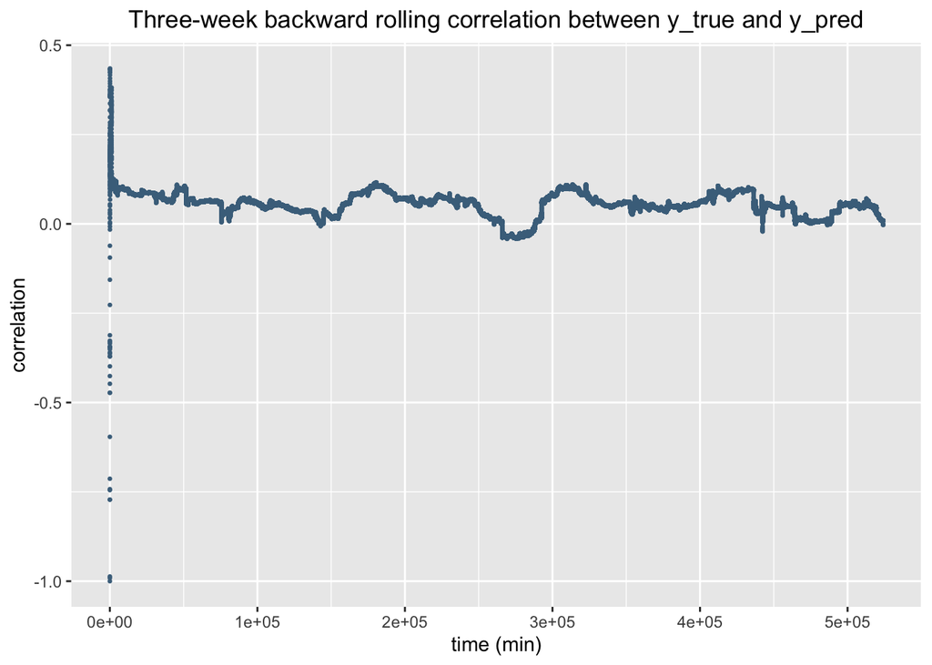

  **Figure 1.** *Three-week backward rolling correlation between true forward return and predicted forward return*

##### **(2). Model 2 - KNN**

- Outcome: $r_f(t, 10)$ of Asset 1.
- Predictors: $r_b(t,3)$, $r_b(t,10)$, $r_b(t,30)$ of the three Assets.
- Graph for finding best K.

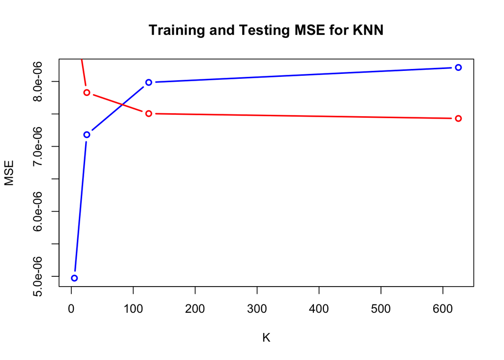

  **Figure 2.** *Training and Testing MSE for KNN*

  - The best K value range we use is {5, 25, 125, 625}. And the best K value we found is 625.

##### **(3). Model 3 - Ridge**

- Predictors: $r_b(t,h)$ of the three Assets, where h $\in$ { 3, 10, 30, 60, 120, 180, 240, 360, 480, 600, 720, 960, 1200, 1440 }.
- Best $\lambda$ selection: The best tuning parameter ($\lambda$) in Ridge selected by validation MSE is 0.004793031.

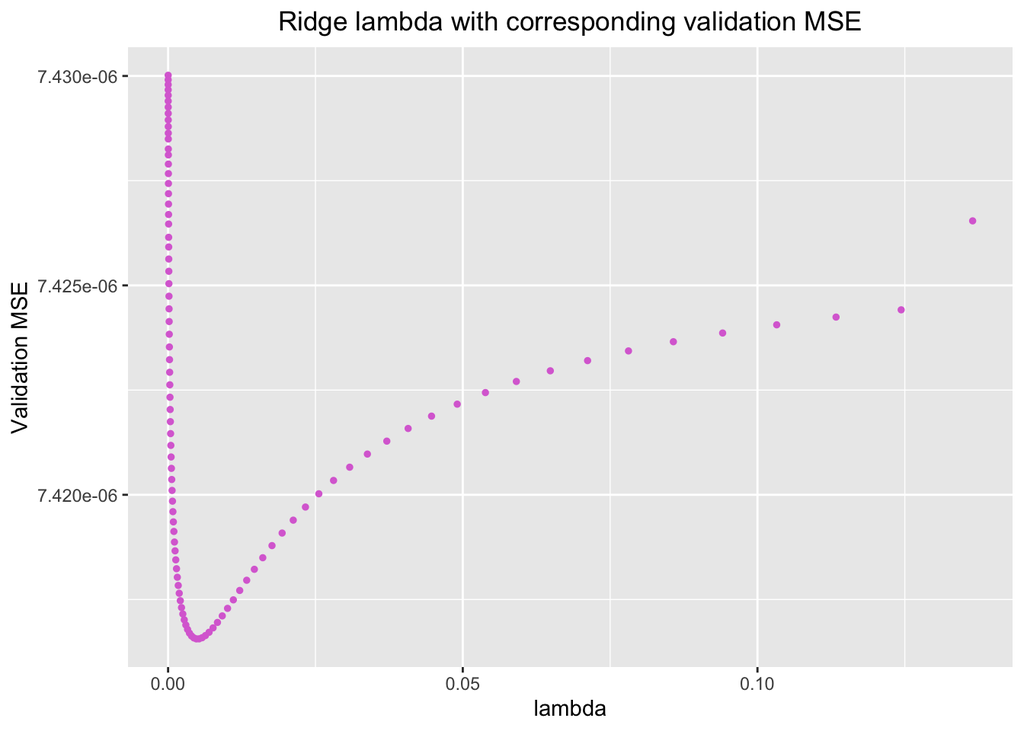

  **Figure 3.** *Validation MSE versus ridge lambda*

##### **(4). Model 4 - LASSO**

- Predictors: $r_b(t,h)$ of the three Assets, where h $\in$ { 3, 10, 30, 60, 120, 180, 240, 360, 480, 600, 720, 960, 1200, 1440 }.
- Best $\lambda$ selection: The best tuning parameter ($\lambda$) in lASSO selected by validation MSE is 4.469997e-05.

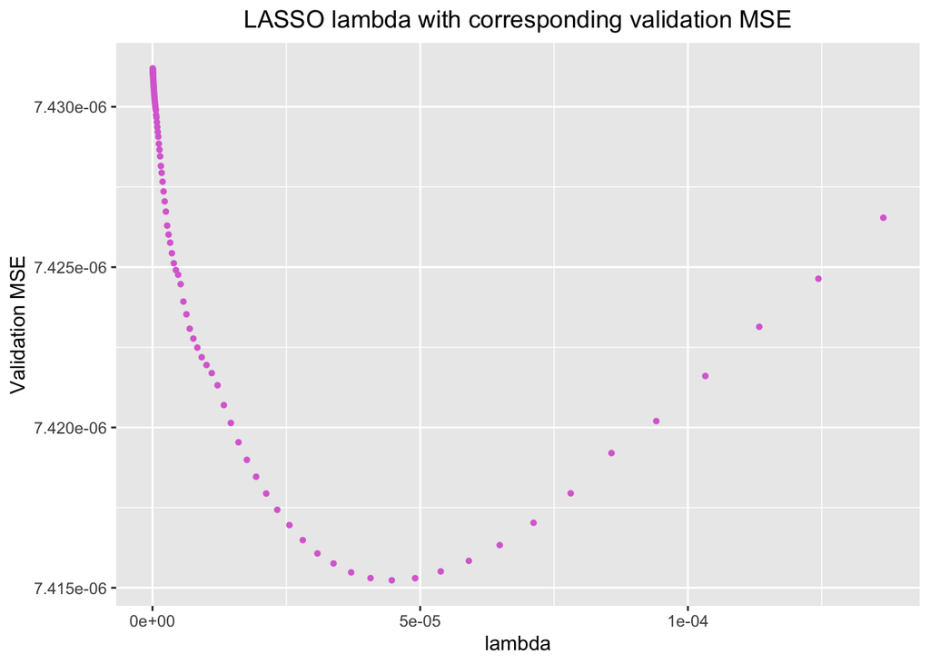

  **Figure 4.** *Validation MSE versus LASSO lambda*

#### **2. Correlation Table:**

**Table 1.** *In-sample and out-of-sample correlation of models*

| Model | in-sample correlation | out-of-sample correlation |
| --- | --- | --- |
| Linear Model | 0.0675 | 0.0404 |
| KNN Model | 0.1320 | 0.0392 |
| Ridge Model | 0.0740 | 0.0369 |
| LASSO Model | 0.0683 | 0.0389 |

### **Part II. Final Prediction**

##### *In the final prediction part, it mainly contains three steps:*

- Add more predictors.
  - Use LASSO to select the variables.
  - Use linear regression to fit the model based on the selected variables and do the prediction.

*The code for this part can be found in `prediction.R`.*

**`prediction.R`**

```r
## Final Model Prediction:
##
##
##
## Author: Yawen Hu
## Updated: November 17, 2020

# 79: -------------------------------------------------------------------------
# libraries: ------------------------------------------------------------------
library(tidyverse)
library(ggplot2)
library(glmnet)

# directories: ----------------------------------------------------------------
setwd("~/Desktop/urop/")

# data: -----------------------------------------------------------------------
foo = load("./data/price_data.RData")

# function: --------------------------------------------------------------------
# I. Add more predictors to the data set:
fret_new = fret
for(j in c(1, 2, 5)){
  for(i in 1:3){
    fret_new = bret_dataframe(fret_new, i, j)
  }
}

# II. Predictor Selection by LASSO Model:
train_size <- nrow(fret_new)*0.7
train_id <- 1:train_size

train_RL <- fret_new[train_id, ]
test_RL <- fret_new[-train_id, ]
X = model.matrix(Asset_1_FRet_10 ~., fret_new)[, -1]
y = fret_new$Asset_1_FRet_10

lasso_mod =glmnet(X[train_id,], y[train_id], alpha=1)

#### Best lambda through validation MSE
n = length(lasso_mod$lambda)
MSE_lasso = c()

for (i in 1:n) {
  lasso_pred_test =predict(lasso_mod, s = lasso_mod$lambda[i], newx = X[-train_id,] )
  MSE_lasso[i] =  mean( (lasso_pred_test - y[-train_id])^2 )
}
#### find the best lambda:
lasso_lambda = data.frame( lambda = lasso_mod$lambda, MSE = MSE_lasso )
best_lasso_lambda = lasso_mod$lambda[which.min(MSE_lasso)]

#### use the optimal lambda for the model:
lasso_pred = predict(lasso_mod, s = best_lasso_lambda, newx = X)
lasso_coef = predict(lasso_mod, s = best_lasso_lambda, type = "coefficients")
lasso_coef

# III. Use selected variable to fit the Final Linear Model:
fret_new = fret_new %>%
  select(c(Asset_1_BRet_1, Asset_2_BRet_1, Asset_3_BRet_1, Asset_1_BRet_2,
           Asset_2_BRet_2, Asset_3_BRet_2, Asset_1_BRet_5, Asset_2_BRet_5,
           Asset_2_BRet_30, Asset_1_BRet_30, Asset_1_BRet_10, Asset_2_BRet_3,
           Asset_1_BRet_3, Asset_1_FRet_10))

train_size = nrow(fret_new)*0.7
train_id = 1:train_size

train_lm <- fret_new[train_id, ]
test_lm <- fret_new[-train_id, ]

### (3) Fit Linear Model - lmod.
final_mod = lm(Asset_1_FRet_10 ~., train_lm)
summary(final_mod)

#### (4) In-sample and Out-of-sample correlation.

##### in-sample correlation:
y_true_train_final = train_lm$Asset_1_FRet_10
y_pred_train_final = predict(final_mod, train_lm)
cor_in_sample_final= cor(y_true_train_final, y_pred_train_final)

##### out-of-sample correlation:
y_true_test_final = test_lm$Asset_1_FRet_10
y_pred_test_final = predict(final_mod, test_lm)
cor_out_sample_final = cor(y_true_test_final, y_pred_test_final)


save(cor_in_sample_final, cor_out_sample_final, file = "prediction.RData")

# 79: -------------------------------------------------------------------------
```

#### **1. Variable Selected by LASSO:**

- Asset 1: $r_b(t,1)$, $r_b(t,2)$, $r_b(t,3)$, $r_b(t,5)$, $r_b(t,10)$, $r_b(t,30)$.
- Asset 2: $r_b(t,1)$, $r_b(t,2)$, $r_b(t,3)$, $r_b(t,5)$, $r_b(t,30)$.
- Asset 3: $r_b(t,1)$, $r_b(t,2)$.

#### **2. Correlation Table:**

**Table 2.** *In-sample and out-of-sample correlation of models (with the Final Model)*

| Model | in-sample correlation | out-of-sample correlation |
| --- | --- | --- |
| Linear Model | 0.0675 | 0.0404 |
| KNN Model | 0.1320 | 0.0392 |
| Ridge Model | 0.0740 | 0.0369 |
| LASSO Model | 0.0683 | 0.0389 |
| Final Model | 0.0644 | 0.0428 |

- From the updated table, we find that the final model has the highest out-of-sample correlation(0.04283438), which indicates the best performance on prediction of forward return.